# 5th_all_assignment_task_machine_learning

## Student Detials

> Title= "Mr"\ Name= "Ali Nawaz"\ email = "nawazktk99@gmail.com"\ whatsapp = "03358043653"

## What is machine learning?

Machine learning creates a useful model or program by autonomously testing many solutions against the available data and finding the best fit for the problem. This means machine learning can be great for solving problems that are extremely labor intensive for humans. It can inform decisions and make predictions about complex topics in an efficient and reliable way.

These strengths make machine learning useful in a huge number of different industries. The possibilities for machine learning are vast. This technology has the potential to save lives and solve important problems in healthcare, computer security and more.

# How Machine Learning Works?

Machine Learning is, undoubtedly, one of the most exciting subsets of Artificial Intelligence. It completes the task of learning from data with specific inputs to the machine. It’s important to understand what makes Machine Learning work and, thus, how it can be used in the future.

The Machine Learning process starts with inputting training data into the selected algorithm. Training data being known or unknown data to develop the final Machine Learning algorithm. The type of training data input does impact the algorithm, and that concept will be covered further momentarily.

New input data is fed into the machine learning algorithm to test whether the algorithm works correctly. The prediction and results are then checked against each other.

If the prediction and results don’t match, the algorithm is re-trained multiple times until the data scientist gets the desired outcome. This enables the machine learning algorithm to continually learn on its own and produce the optimal answer, gradually increasing in accuracy over time.

## What are the Different Types of Machine Learning?

Machine Learning is complex, which is why it has been divided into two primary areas, supervised learning and unsupervised learning. Each one has a specific purpose and action, yielding results and utilizing various forms of data. Approximately 70 percent of machine learning is supervised learning, while unsupervised learning accounts for anywhere from 10 to 20 percent. The remainder is taken up by reinforcement learning.

### 1. Supervised Learning

In supervised learning, we use known or labeled data for the training data. Since the data is known, the learning is, therefore, supervised, i.e., directed into successful execution. The input data goes through the Machine Learning algorithm and is used to train the model. Once the model is trained based on the known data, you can use unknown data into the model and get a new response.

### Supervised Learning

In this case, the model tries to figure out whether the data is an apple or another fruit. Once the model has been trained well, it will identify that the data is an apple and give the desired response.

### 2. Semi-Supervised

Semi-supervised machine learning is a combination of supervised and unsupervised machine learning methods.

With more common supervised machine learning methods, you train a machine learning algorithm on a “labeled” dataset in which each record includes the outcome information. This allows the algorithm to deduce patterns and identify relationships between your target variable and the rest of the dataset based on information it already has. In contrast, unsupervised machine learning algorithms learn from a dataset without the outcome variable. In semi-supervised learning, an algorithm learns from a dataset that includes both labeled and unlabeled data, usually mostly unlabeled.

### 3. Unsupervised Learning

In unsupervised learning, the training data is unknown and unlabeled - meaning that no one has looked at the data before. Without the aspect of known data, the input cannot be guided to the algorithm, which is where the unsupervised term originates from. This data is fed to the Machine Learning algorithm and is used to train the model. The trained model tries to search for a pattern and give the desired response. In this case, it is often like the algorithm is trying to break code like the Enigma machine but without the human mind directly involved but rather a machine.

#### Unsupervised Learning

In this case, the unknown data consists of apples and pears which look similar to each other. The trained model tries to put them all together so that you get the same things in similar groups.

The top 7 algorithms currently being used for unsupervised learning are:

- Partial least squares
- Fuzzy means
- Singular value decomposition
- K-means clustering
- Apriori
- Hierarchical clustering
- Principal component analysis

### 4. Reinforcement Learning

Like traditional types of data analysis, here, the algorithm discovers data through a process of trial and error and then decides what action results in higher rewards. Three major components make up reinforcement learning: the agent, the environment, and the actions. The agent is the learner or decision-maker, the environment includes everything that the agent interacts with, and the actions are what the agent does.

Reinforcement learning occurs when the agent chooses actions that maximize the expected reward over a given time. This is easiest to achieve when the agent is working within a sound policy framework.

### Herein, we share few examples of machine learning that we use everyday and perhaps have no idea that they are driven by ML.

- Virtual Personal Assistants. ...
- Predictions while Commuting. ...
- Videos Surveillance. ...
- Social Media Services. ...
- Email Spam and Malware Filtering. ...
- Online Customer Support. ...
- Search Engine Result Refining.
- etc

### In this Notebook we are going to know about Simple Linear Regression

```python
# import all the lib
import pandas as pd
import seaborn as sns
import numpy as np
import sklearn.metrics as sm
import matplotlib.pyplot as plt
```

1. Loading data Firstly, we will use the Python Pandas library to read our CSV data.

```python
# import all the lib
import pandas as pd
import seaborn as sns
import numpy as np
from sklearn.model_selection import train_test_split
from sklearn import linear_model
import sklearn.metrics as sm
import matplotlib.pyplot as plt

# Importing Linear Regression model from scikit learn
from sklearn.linear_model import LinearRegression
# Importing metrics for the evaluation of the model
from sklearn.metrics import r2_score,mean_squared_error
#Import knearest neighbors Classifier model
from sklearn.neighbors import KNeighborsClassifier
# Importing Linear Regression model from scikit learn
from sklearn.linear_model import LinearRegression
# Importing metrics for the evaluation of the model
from sklearn.metrics import r2_score,mean_squared_error
from sklearn.tree import DecisionTreeClassifier # Import Decision Tree Classifier
from sklearn.model_selection import train_test_split # Import train_test_split function
from sklearn import metrics #Import scikit-learn metrics module for accuracy calculation
from sklearn.metrics import confusion_matrix
from sklearn.metrics import classification_report
from sklearn.metrics import roc_curve
from sklearn.metrics import roc_auc_score
from sklearn.metrics import precision_recall_curve
from sklearn.metrics import auc
import matplotlib.pyplot as plt
# read the dataset using pandas

# read the dataset using pandas
data = pd.read_csv('D:/Python ka Chilla/python_chilla/data/Salary_Data.csv')
```

```python
# This displays the top 5 rows of the data
data.head()
```

|  | YearsExperience | Salary |
| --- | --- | --- |
| 0 | 1.1 | 39343.0 |
| 1 | 1.3 | 46205.0 |
| 2 | 1.5 | 37731.0 |
| 3 | 2.0 | 43525.0 |
| 4 | 2.2 | 39891.0 |

```python
# Provides some information regarding the columns in the data
data.info()
```

```
<class 'pandas.core.frame.DataFrame'>
RangeIndex: 30 entries, 0 to 29
Data columns (total 2 columns):
 #   Column           Non-Null Count  Dtype
---  ------           --------------  -----
 0   YearsExperience  30 non-null     float64
 1   Salary           30 non-null     float64
dtypes: float64(2)
memory usage: 608.0 bytes
```

```python
# this describes the basic stat behind the dataset used
data.describe()
```

|  | YearsExperience | Salary |
| --- | --- | --- |
| count | 30.000000 | 30.000000 |
| mean | 5.313333 | 76003.000000 |
| std | 2.837888 | 27414.429785 |
| min | 1.100000 | 37731.000000 |
| 25% | 3.200000 | 56720.750000 |
| 50% | 4.700000 | 65237.000000 |
| 75% | 7.700000 | 100544.750000 |
| max | 10.500000 | 122391.000000 |

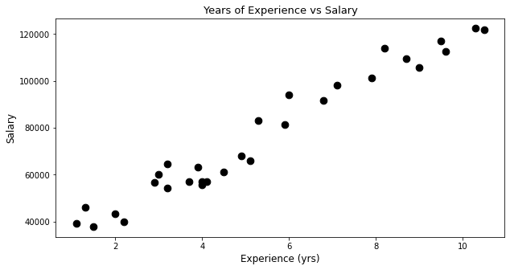

```python
plt.figure(figsize=(10,5))
plt.title('Years of Experience vs Salary', fontsize=13)
plt.xlabel('Experience (yrs)', fontsize=12)
plt.ylabel('Salary', fontsize=12)
plt.scatter(data.YearsExperience, data.Salary, s=75, color='black')
plt.show()
```

```python
# Cooking the data
X = data['YearsExperience']
X.head()
```

```
0    1.1
1    1.3
2    1.5
3    2.0
4    2.2
Name: YearsExperience, dtype: float64
```

```python
# Cooking the data
y = data['Salary']
y.head()
```

```
0    39343.0
1    46205.0
2    37731.0
3    43525.0
4    39891.0
Name: Salary, dtype: float64
```

```python
# Split the data for train and test
X_train,X_test,y_train,y_test = train_test_split(X,y,train_size=0.7,random_state=100)
```

```python
# Create new axis for x column
X_train = X_train[:,np.newaxis]
X_test = X_test[:,np.newaxis]
```

```python
# Fitting the model
lr = LinearRegression()
lr.fit(X_train,y_train)
```

```
LinearRegression()
```

```python
# Predicting the Salary for the Test values
y_pred = lr.predict(X_test)
```

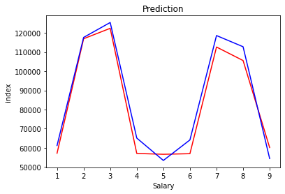

```python
# Plotting the actual and predicted values

c = [i for i in range (1,len(y_test)+1,1)]
plt.plot(c,y_test,color='r',linestyle='-')
plt.plot(c,y_pred,color='b',linestyle='-')
plt.xlabel('Salary')
plt.ylabel('index')
plt.title('Prediction')
plt.show()
```

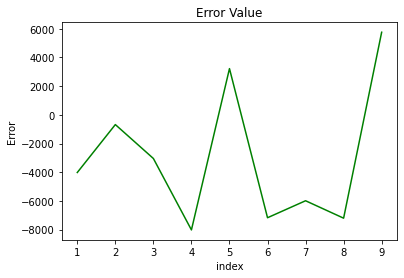

```python
# plotting the error
c = [i for i in range(1,len(y_test)+1,1)]
plt.plot(c,y_test-y_pred,color='green',linestyle='-')
plt.xlabel('index')
plt.ylabel('Error')
plt.title('Error Value')
plt.show()
```

```python
# calculate Mean square error
mse = mean_squared_error(y_test,y_pred)
```

```python
# Calculate R square vale
rsq = r2_score(y_test,y_pred)
```

```python
print('mean squared error :',mse)
print('r square :',rsq)
```

```
mean squared error : 30310299.043402452
r square : 0.9627668685473267
```

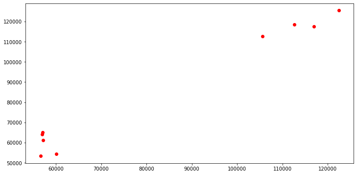

```python
# Just plot actual and predicted values for more insights
plt.figure(figsize=(12,6))
plt.scatter(y_test,y_pred,color='r',linestyle='-')
plt.show()
```

```python
# Intecept and coeff of the line
print('Intercept of the model:',lr.intercept_)
print('Coefficient of the line:',lr.coef_)
```

```
Intercept of the model: 25202.887786154883
Coefficient of the line: [9731.20383825]
```

### Class Students Data with Machine Learning

```python
# load dataset
df = pd.read_csv("D:/Python ka Chilla/python_chilla/data/mldata.csv")
df['age'] = df['age'].astype(float)
df['weight'] = df['weight'].astype(float)
df['height'] = df['height'].astype(float)
df.head()
```

|  | age | weight | gender | likeness | height |
| --- | --- | --- | --- | --- | --- |
| 0 | 27.0 | 76.0 | Male | Biryani | 170.688 |
| 1 | 41.0 | 70.0 | Male | Biryani | 165.000 |
| 2 | 29.0 | 80.0 | Male | Biryani | 171.000 |
| 3 | 27.0 | 102.0 | Male | Biryani | 173.000 |
| 4 | 29.0 | 67.0 | Male | Biryani | 164.000 |

```python
# Take relevant data
workshop_data = df[["age","weight","height"]]
workshop_data.head()
```

|  | age | weight | height |
| --- | --- | --- | --- |
| 0 | 27.0 | 76.0 | 170.688 |
| 1 | 41.0 | 70.0 | 165.000 |
| 2 | 29.0 | 80.0 | 171.000 |
| 3 | 27.0 | 102.0 | 173.000 |
| 4 | 29.0 | 67.0 | 164.000 |

```python
X = workshop_data.iloc[:, :-1].values #get a copy of dataset exclude last column
y = workshop_data.iloc[:, 1].values #get array of dataset in column 1st
```

```python
import plotly.express as px
fig = px.imshow(workshop_data.corr())
fig.show()
```

```python
X_train,X_test,y_train,y_test = train_test_split(X,y,test_size=.33,random_state=42)
```

```python
col = ['X_train', 'X_test', 'y_train', 'y_test']
data = [X_train, X_test, y_train, y_test]
for i in range(len(col)):
    print(f'Shape of {col[i]}: {data[i].shape}')
```

[output not shown]

```python
from sklearn.linear_model import LinearRegression
lr = LinearRegression()
lr.fit(X_train, y_train)
```

```
LinearRegression()
```

```python
#Prediciting Y from Linear regression Model
y_pred = lr.predict(X_test)
```

```python
x_range = np.linspace(X.min(), X.max(), 100)
y_range = lr.predict(x_range.reshape(-1, 1))

fig = go.Figure([
        go.Scatter(x=X_train.squeeze(), y=y_train,
                   name='train', mode='markers'),
        go.Scatter(x=X_test.squeeze(), y=y_test,
                   name='test', mode='markers'),
        go.Scatter(x=x_range, y=y_range,
                   name='prediction')
    ])

fig.show()
```

[output not shown]

```python
#Assigning Coefficient (slope) to b
b = lr.coef_
```

```python
print("Coefficient  :" , b)
```

```
Coefficient  : [-8.3603836e-17  1.0000000e+00]
```

```python
#Assigning Y-intercept to a
a = lr.intercept_
```

```python
print("Intercept : ", a)
```

```
Intercept :  -1.4210854715202004e-14
```

```python
#y_predict(11)
print(lr.predict([[11]]))
```

[output not shown]

```python
regr = LinearRegression()
regr.fit(X_train, y_train)
print(f'Coefficients: {regr.coef_}')
print(f'Intercepts: {regr.intercept_}')
```

```
Coefficients: [-4.6705726e-16  1.0000000e+00]
Intercepts: -1.4210854715202004e-14
```

```python
fig, ax = plt.subplots(1, 2, figsize=(15, 5))
ax[0].set_title('Training Set', fontsize=15)
ax[0].scatter(X_train, y_train, color='black')
ax[0].plot(X_train, regr.coef_*X_train + regr.intercept_, '-r')
ax[0].set_xlabel('Experience (yrs)')
ax[0].set_ylabel('Salary')
ax[1].set_title('Testing Set', fontsize=15)
ax[1].scatter(X_test, y_test,  color='black')
ax[1].plot(X_test, regr.coef_*X_test + regr.intercept_, '-r')
ax[1].set_xlabel('Experience (yrs)')
ax[1].set_ylabel('Salary')
plt.show()
```

[output not shown]

```python
fig, ax = plt.subplots(1, 2, figsize=(15, 5))
ax[0].set_title('Training Set', fontsize=15)
ax[0].scatter(X_train, y_train, s=75, color='black')
ax[0].set_xlabel('Experience (yrs)')
ax[0].set_ylabel('Salary')
ax[1].set_title('Testing Set', fontsize=15)
ax[1].scatter(X_test, y_test, s=75, color='black')
ax[1].set_xlabel('Experience (yrs)')
ax[1].set_ylabel('Salary')
plt.show()
```

[output not shown]

[figure not shown]

```python
# These Plots help to explain the values and how they are scattered

plt.figure(figsize=(12,6))
sns.pairplot(data,x_vars=['YearsExperience'],y_vars=['Salary'],size=7,kind='scatter')
plt.xlabel('Years')
plt.ylabel('Salary')
plt.title('Salary Prediction')
plt.show()
```

```python
regressor = LinearRegression()
regressor.fit(X_train, y_train)
```

```
LinearRegression()
```

```python
# Predicting the Test set results
y_pred = regressor.predict(X_test)
```

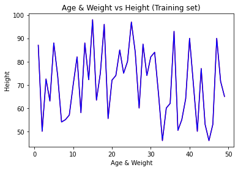

```python
# Plotting the actual and predicted values

c = [i for i in range (1,len(y_test)+1,1)]
plt.plot(c,y_test,color='r',linestyle='-')
plt.plot(c,y_pred,color='b',linestyle='-')
plt.xlabel('Age & Weight')
plt.ylabel('Height')
plt.title('Age & Weight vs Height (Training set)')
plt.show()
```

```python
# Visualizing the Training set results
viz_train = plt
viz_train.scatter(X_train[:,0], y_train, color='red')
viz_train.plot(X_train[:,0], regressor.predict(X_train[:,0]), color='blue')
viz_train.title('Age & Weight vs Height (Training set)')
viz_train.xlabel('Age & Weight')
viz_train.ylabel('Height')
viz_train.show()
```

[output not shown]

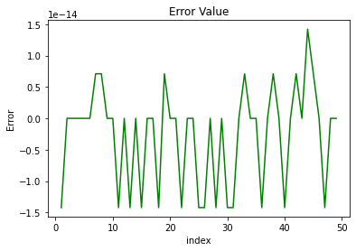

```python
# plotting the error
c = [i for i in range(1,len(y_test)+1,1)]
plt.plot(c,y_test-y_pred,color='green',linestyle='-')
plt.xlabel('index')
plt.ylabel('Error')
plt.title('Error Value')
plt.show()
```

## Linear Regression Assignment

## Model Fiting

```python
model = LinearRegression().fit(X_train, y_train)
```

# Ploting train model

[figure not shown]

```python
plt.scatter(X_train, y_train)
plt.plot(X_train, model.predict(X_train))
plt.ylabel("Salary")
plt.xlabel("Experince")
plt.title("Salary vs Experience Plot")
```

[figure not shown]

```python
plt.scatter(X_test, y_test)
plt.plot(X_train, model.predict(X_train))
plt.ylabel("Salary")
plt.xlabel("Experince")
plt.title("Salary vs Experience Plot on Test Data")
```

## Evaluating model or Testing model

```python
print('Testing Score of Model:', model.score(X_test, y_test))

print('Training Score of Model:',model.score(X_train, y_train))
```

[output not shown]

```python
# Predict on new data and data should be 2 D
x = [[5]]
model.predict(x)
```

[output not shown]

## What is a Regression

In Regression, we plot a graph between the variables which best fit the given data points. The machine learning model can deliver predictions regarding the data. In naïve words, “Regression shows a line or curve that passes through all the data points on a target-predictor graph in such a way that the vertical distance between the data points and the regression line is minimum.” It is used principally for prediction, forecasting, time series modeling, and determining the causal-effect relationship between variables.

## Types of Regression models

1. Linear Regression
2. Polynomial/Multi Regression
3. Logistics Regression

## Multi Linear Regression

Multiple Linear Regression is basically indicating that we will be having many features Such as f1, f2, f3, f4, and our output feature f5. If we take the same example as above we discussed, suppose:

f1 is the size of the house.

f2 is bad rooms in the house.

f3 is the locality of the house.

f4 is the condition of the house and,

f5 is our output feature which is the price of the house.

Now, you can see that multiple independent features also make a huge impact on the price of the house, price can vary from feature to feature. When we are discussing multiple linear regression then the equation of simple linear regression y=A+Bx is converted to something like:

```
                        equation:  y = A+B1x1+B2x2+B3x3+B4x4
```

“If we have one dependent feature and multiple independent features then basically call it a multiple linear regression.”

[figure not shown]

Now, our aim to using the multiple linear regression is that we have to compute A which is an intercept, and B1 B2 B3 B4 which are the slops or coefficient concerning this independent feature, that basically indicates that if we increase the value of x1 by 1 unit then B1 says that how much value it will affect int he price of the house, and this was similar concerning others B2 B3 B4

So, this is a small theoretical description of multiple linear regression now we will use the scikit learn linear regression library to solve the multiple linear regression problem.

x in independent but y is depends on x values so it's the correct form.

```python
df = pd.read_csv('D:/Python ka Chilla/python_chilla/data/ml_data_salary.csv')
df.head()
```

|  | age | distance | YearsExperience | Salary |
| --- | --- | --- | --- | --- |
| 0 | 31.1 | 77.75 | 1.1 | 39343 |
| 1 | 31.3 | 78.25 | 1.3 | 46205 |
| 2 | 31.5 | 78.75 | 1.5 | 37731 |
| 3 | 32.0 | 80.00 | 2.0 | 43525 |
| 4 | 32.2 | 80.50 | 2.2 | 39891 |

```python
X = df[['age','distance','YearsExperience']]
y = df[['Salary']]
```

```python
X_train, X_test, y_train, y_test = train_test_split(X, y, test_size=0.2, random_state=0)
```

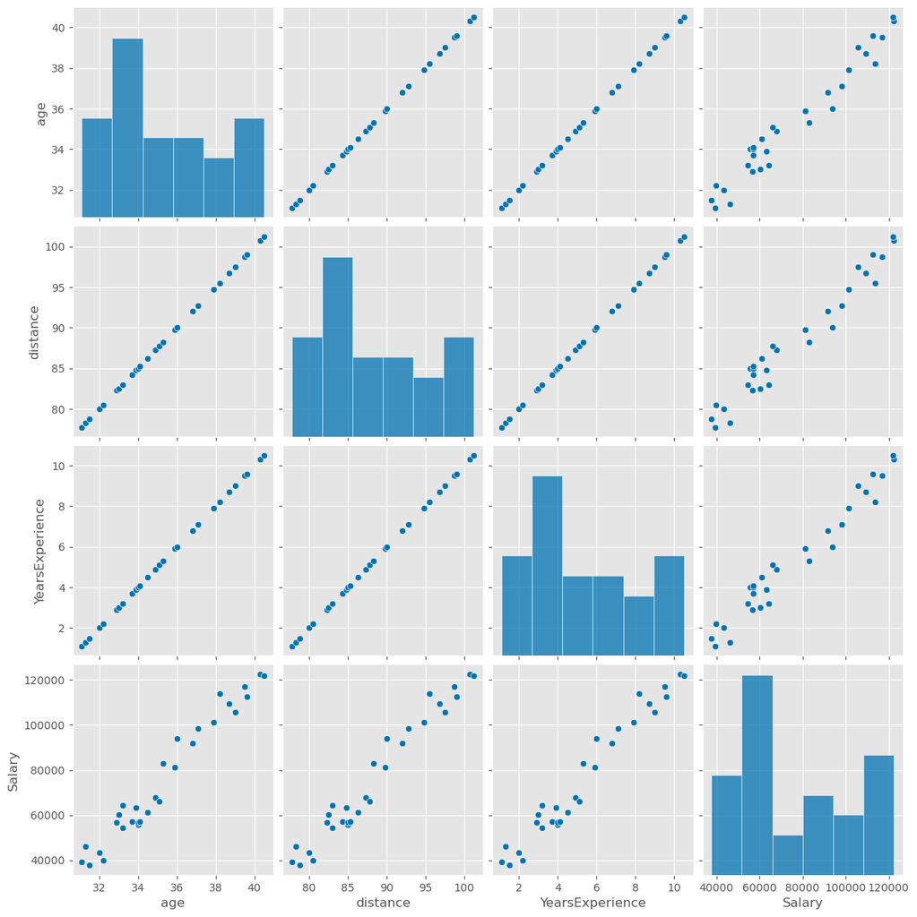

```python
sns.set_palette('colorblind')
sns.pairplot(data=df, height=3)
```

## Model Fiting

```python
model = LinearRegression().fit(X_train, y_train)
```

```python
model.coef_
```

```
array([[-7.88818945e+15,  1.95412592e+14,  7.39965797e+15]])
```

```python
model.intercept_
```

```
array([2.21989739e+17])
```

```python
print('Intercept:', model.intercept_)
print('Coefficients:', model.coef_)
```

```
Intercept: [2.21989739e+17]
Coefficients: [[-7.88818945e+15  1.95412592e+14  7.39965797e+15]]
```